# testRmarkdown

This is a continuation of the data exploration for my Research Methods project using R. The last installment can be found [here](http://ericagunn.com/2016/02/12/researchmethods-exploration-of-land-use-data/)

I am continuing to work my way through the World Bank data on land use as a way to familiarize myself with R. Land use is interesting because it is one of the primary factors that influence the organic carbon content of soil.

So far, I have worked with only one dataset from the World Bank at a time. Each one is saved in a separate .csv file, and needs to be loaded individually. Today, my goal was to combine two loaded datasets into a single R dataframe and plot the information.

First, I started by loading the total land area dataset for all of the countries in the world. (Actually, it turned out that the raw file included information for each region, continent, and several economic classes as well…I cut those out manually for now.)

I chose to use only the 50 largest countries, to reduce the number of data points that I had to plot at one time. Comparing the total area for these 50 countries with the world total land area shows that they make up about 87% of the total available land, so this should still give a pretty good idea of what’s going on in the data.

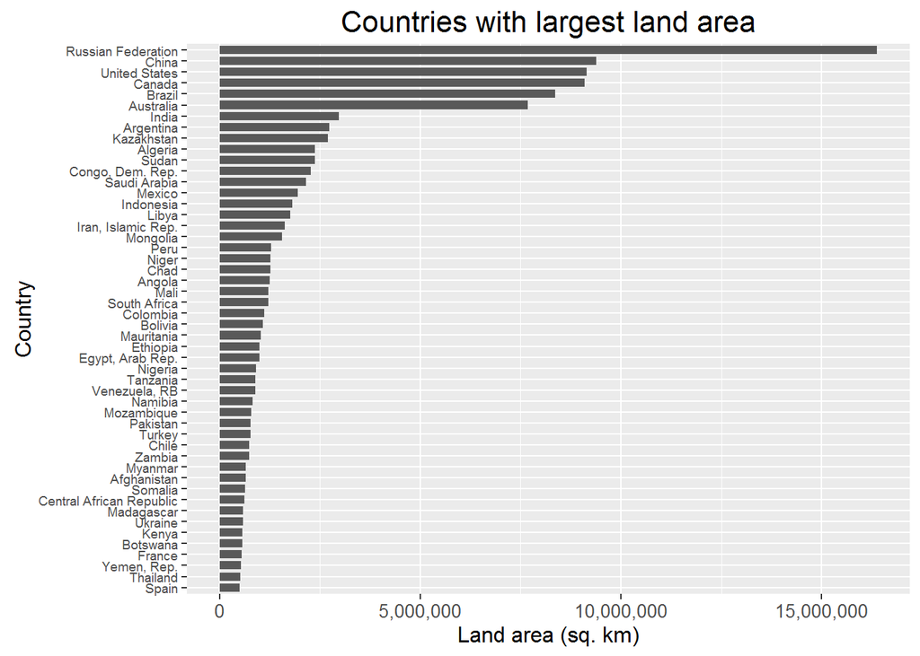

Next, I loaded the file containing information on the percentage of agricultural land for each country. Again, I used the 50 largest countries to reduce the amount of information to plot, and kept them in the same order to facilitate comparisons.

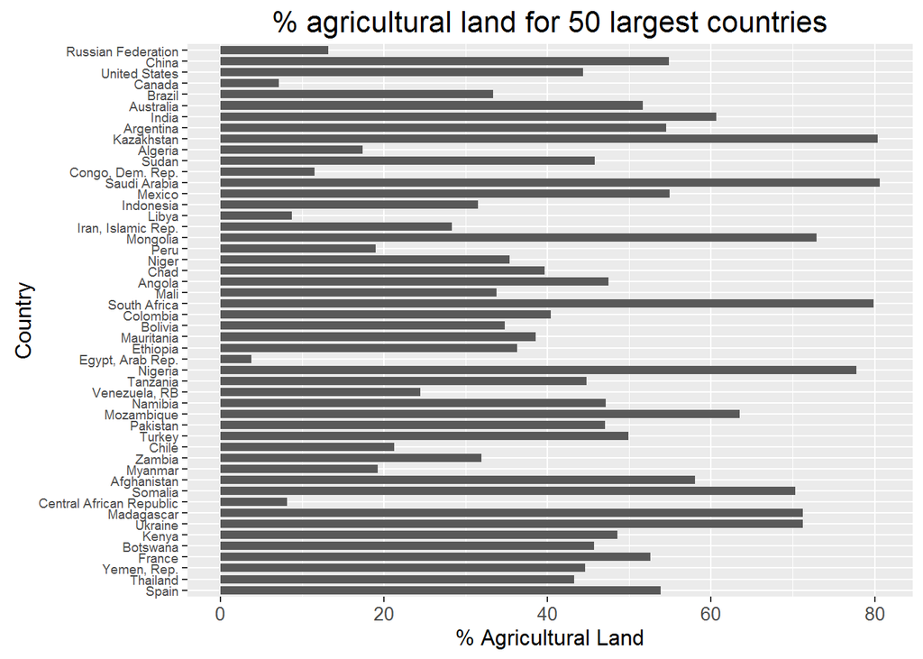

I was really surprised to see Saudi Arabia among the highest percentages of agricultural land. I don’t think of that being a particularly agricultural country, but it appears that it is. Kazakhstan, South Africa, and Nigeria are also at the top of the list. (I double-checked that this was correct in the original spreadsheet, just to make sure I hadn’t mixed something up during processing in R.)

Really, I wanted to compare the agricultural and total land areas for each country, and it would be easier to see relative sizes if the two variables were together on the same plot. So, I calculated the agricultural land area using the percentage value and the country’s total land area, and plotted both variables together.

Getting the plots to show up properly takes quite a bit of code:

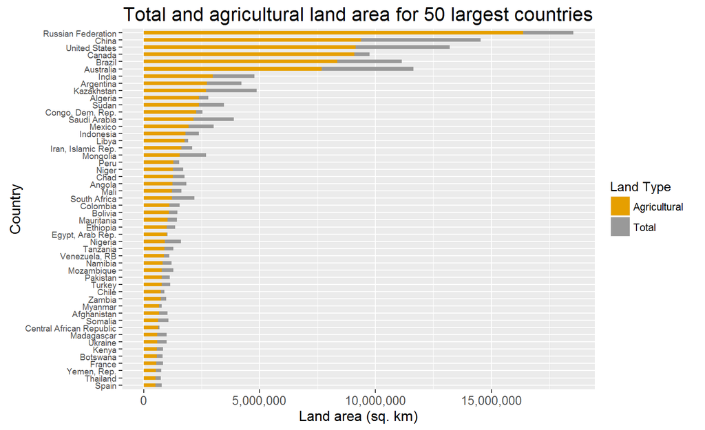

```r
ggplot(data=cutMelt, aes(x=cutMelt$factor, y=cutMelt$value,fill=cutMelt$x2013))+
  geom_bar(width=.5,stat="identity")+
  coord_flip()+
  labs(title="Total and agricultural land area for 50 largest countries",
       x="Country",
       y = "Land area (sq. km)")+
  scale_y_continuous(labels=comma)+
  theme(axis.title.x = element_text(size=12),
        axis.title.y = element_text(size=12),
        axis.text.x = element_text(size =10),
        axis.text.y = element_text(size =7),
        plot.title=element_text(size=16))+
  scale_fill_manual(values=c("#E69F00","#999999"),
        name="Land Type",
        breaks=c("X2013", "absAgricArea"),
        labels=c("Agricultural", "Total"))
```